# Social Stratification in Medellín

Manuela Szinovatz

The following analysis is based on data from the Colombian government and was originally collected for the social program “Sisbén” (https://www.sisben.gov.co/sisben/paginas/que-es.aspx) that helps the government to allocate subsidies to people in need.

The data can be downloaded here: https://www.datos.gov.co/Salud-y-Protecci-n-Social/Base-de-Datos-Sisben-2017-Municipio-de-Medell-n/cnr8-armb

The dataset consists of 1,726,698 individual records. Each record accounts for one person living in Medellín’s urban area and gives information about her/his socioeconomic situation. The data is anonymous. Although the sample is very big its accuracy varies slightly. Fewer data is available in the richer neighbourhoods, where fewer people rely on help from the social Sisbén system. This gets particularly clear looking at Comuna 14, Poblado, where out of approximately 130,000 inhabitants only 5,670 records can be found in the Sisbén dataset. In poorer districts and neighbourhoods usually between 80 and 100 percent are recorded. This leads to the assumption that the already very obvious difference between the richer and the poorer districts is even bigger in reality.

Based on that information the following datatable summarises the average Estrato as well as the average level of education and monthly income in Colombian pesos in Medellín’s various neighbourhoods and the respective district (Comuna) the neighbourhood belongs to.

|  | Neighbourhood | District | District Number | Average Estrato | Average Education | Average Monthly Income |
| --- | --- | --- | --- | --- | --- | --- |
| 1 | Aldea Pablo Vi | Popular | 1 | 1 | 1 | 101264 |
| 2 | Alejandria | Poblado | 14 | 2 | 2 | 217876 |
| 3 | Alejandro Echavarria | Buenos Aires | 9 | 3 | 2 | 223213 |
| 4 | Alfonso Lopez | Castilla | 5 | 3 | 2 | 166708 |
| 5 | Altamira | Robledo | 7 | 3 | 2 | 307040 |
| 6 | Altos Del Poblado | Poblado | 14 | 3 | 2 | 349570 |
| 7 | Andalucia | Santa Cruz | 2 | 2 | 1 | 135476 |
| 8 | Andalucia | Buenos Aires | 9 | 2 | 2 | 245906 |
| 9 | Antonio Nariño | Robledo | 7 | 2 | 1 | 150000 |
| 10 | Antonio Nariño | San Javier | 13 | 2 | 1 | 144191 |

[output cut: 317 more lines]

## Looking at Moravia

The following chart shows the exact percentages of people living in Estrato 0 to 4. The higher Estratos 5 and 6 don’t exist in Moravia.

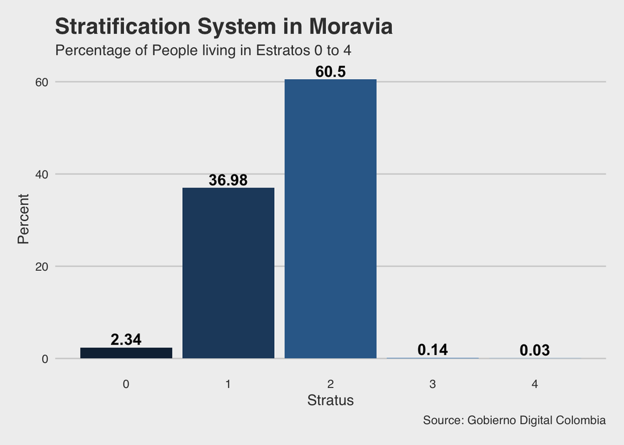